# mle-mm

Zhuoyi Zhan

December 04, 2021

# 1 Introduction

This blog is a tutorial about how to use MLe and MM to model teo variabless: Glycohemoglobin and height of adult females.

# 2 Background

MLE and MM are two method to estimate population parameters.

Method of Moment: its involves equating the sample moments to the k population moments. First choose a distribution, then calculate distribution moments and sample moments. Thenequating distribution’s mean, variance with sample mean, variance to solve for parameter of thef interest.

Maximum Likelihood Estimation: Estimate the unknown parameter that maximizes the log likelihood function given some data. In this way, using the assumed statistical model, the observed sample is most likely.

## 2.1 MM

```r
require(dplyr)
Hmisc::getHdata(nhgh)
d1 <- nhgh %>%
  filter(sex == "female") %>%
  filter(age >= 18) %>%
  select(gh, ht) %>%
  filter(1:n()<=1000)
```

How you calculated estimates of MM parameters: first choose a parametric distribution (normal, gamma, weibull), then identify the distribution parameters. Normal’s mean and median, Gamma distribution has shape and scale.

Gamma distribution: **E[X]=shape∗scale** **V[X]=shape∗scale^2**

The codes has accomplished these tasks: Overlay estimated pdf onto histogram Overlay estimated CDF onto eCDF QQ plot(sample vs estimated dist)

Use p function to find estimated cdf. CDF shows the probability of a value less than or equal to x. Use d function to find PDF, probability density function, that shows probability of a random variable within a range.

Median is calculated by q fucntion which return the value of the intended quantile, median is the 0.5 quantile.

### 2.1.1 MM-Normal Distribution

```r
par(mfrow = c(1,3))
hist(d1$gh, freq = FALSE, main = "Histogram of Glycohemiglobin", breaks=100)
#parameters
(xbar <- mean(d1$gh))
```

```
## [1] 5.7246
```

```r
(s2 <- var(d1$gh))
```

```
## [1] 1.107222
```

```r
#estimated pdf
curve(dnorm(x, mean=xbar, sd = s2),0,14,add=TRUE, lwd=3, col="steelblue")
#norm_median
(norm_median <- qnorm(0.5, mean=xbar, sd = s2))
```

```
## [1] 5.7246
```

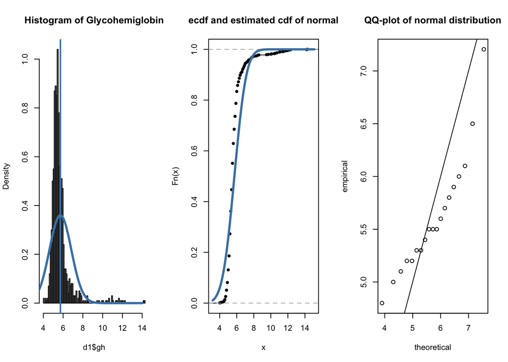

```r
abline(v=norm_median,col="steelblue",lwd=2)

#ecdf, estimated cdf
plot(ecdf(d1$gh),main="ecdf and estimated cdf of normal")
curve(pnorm(x, mean=xbar, sd=s2),add=TRUE, lwd=3, col="steelblue")

#QQplot
sq <- seq(0.05,0.95,by=0.05)
#empirical
qt <- quantile(d1$gh, sq)
#theoretical
qn <- qnorm(sq, mean=xbar, sd=s2)
plot(qn,qt, main="QQ-plot of normal distribution",xlab="theoretical", ylab="empirical")
# y=x line
abline(0,1)
```

The QQplot shows that points does not perfectly fall on the y=x line. This means that estimated distribution does not match the empirical distribution.

### 2.1.2 MM-Gamma

```r
par(mfrow = c(1,3))
hist(d1$gh, freq = FALSE, main = "Histogram of Glycohemiglobin", breaks=100)
#parameters
(shape_hat <- xbar^2/s2)
```

```
## [1] 29.59754
```

```r
(scale_hat <- s2/xbar)
```

```
## [1] 0.1934147
```

```r
#est pdf
curve(dgamma(x, shape=shape_hat, scale=scale_hat),0,14,add =T,lwd=3, col="purple")

#meidan
abline(v=qgamma(0.5, shape=shape_hat, scale=scale_hat),col="purple",lwd=2)
(qgamma(0.5, shape=shape_hat, scale=scale_hat))
```

```
## [1] 5.660259
```

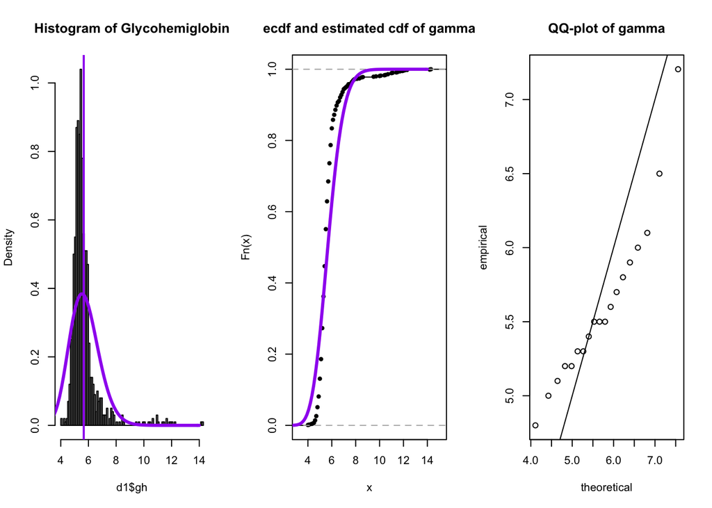

```r
#ecdf
plot(ecdf(d1$gh),main="ecdf and estimated cdf of gamma")
#est ecdf
curve(pgamma(x, shape=shape_hat,scale=scale_hat),0,14,add =T,lwd=3, col="purple")

#QQ-plot
sq <- seq(0.05,0.95,by=0.05)
qt_y <- quantile(d1$gh, sq)
ga_x <- qgamma(sq, shape=shape_hat,scale=scale_hat)

plot(ga_x,qt_y, main="QQ-plot of gamma",xlab="theoretical", ylab="empirical")
abline(0,1)
```

The QQplot shows that points does not perfectly fall on the y=x line. This means that estimated distribution does not match the empirical distribution.

### 2.1.3 MM-weibull

```r
par(mfrow = c(1,3))
#parameters
var.weib <- function(k,m_hat, var_hat){
  mean_w2<- (m_hat/gamma(1+1/k))^2
  var_w <- (gamma(1+2/k)-(gamma(1+1/k))^2)
  out <- mean_w2 * var_w - var_hat
  return(out)
}

x=seq(10,40, by=0.1)
mm.opt <- optimize(f=function(x){
  abs(var.weib(k=x, m_hat=mean(d1$gh),var_hat=var(d1$gh)))
}, lower=10, upper=100)
mm.weib.k <- mm.opt$minimum
mm.weib.lambda=(xbar/gamma(1+1/mm.weib.k))

(shape_weib = mm.weib.k)
```

```
## [1] 10.00008
```

```r
(scale_weib= mm.weib.lambda)
```

```
## [1] 6.017337
```

```r
#est pdf
hist(d1$gh, freq = FALSE, main = "Histogram of Glycohemiglobin", breaks=100)
curve(dweibull(x,shape=shape_weib, scale=scale_weib),0,14, add=T, lwd=3, col="red")
#meidan
abline(v=qweibull(0.5, shape=shape_weib, scale=scale_weib),col="red",lwd=2)
(qweibull(0.5, shape=shape_weib, scale=scale_weib))
```

```
## [1] 5.800788
```

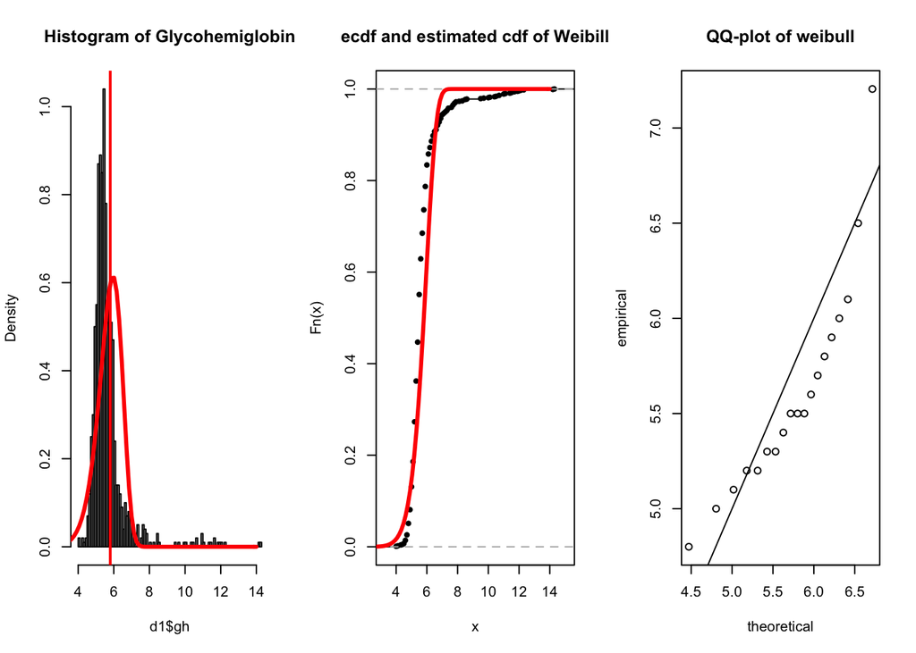

```r
#ecdf
plot(ecdf(d1$gh),main="ecdf and estimated cdf of Weibill")
#est ecdf
curve(pweibull(x, shape=shape_weib,scale=scale_weib),0,14,add =T,lwd=3, col="red")

#QQ-plot
sq <- seq(0.05,0.95,by=0.05)
y_w <- quantile(d1$gh, sq)
x_w <- qweibull(sq, shape=shape_weib,scale=scale_weib)

plot(x_w,y_w, main="QQ-plot of weibull",xlab="theoretical", ylab="empirical")
abline(0,1)
```

The QQplot shows that points does not perfectly fall on the y=x line. This means that estimated distribution does not match the empirical distribution. But it seems that Weibull distribution performs better than normal and gamma distribution.

## 2.2 MLE

To solve for unknown parameters, you first construct a joint probability mass function which is also the likelihood function. for mathematical ease, we actually work with the log likelihood function. Finally use optimization to find parameters that maximize the likelihood function.

nll is the negative likelihood function that needs to be minimized, it is the same as maximizing the log likelihood. The it fit funciton, we need to put in stating point as guess for the parameters. BFGS is a method to optimize the likelihood function.

### 2.2.1 MLE-normal

```r
require(stats4)
```

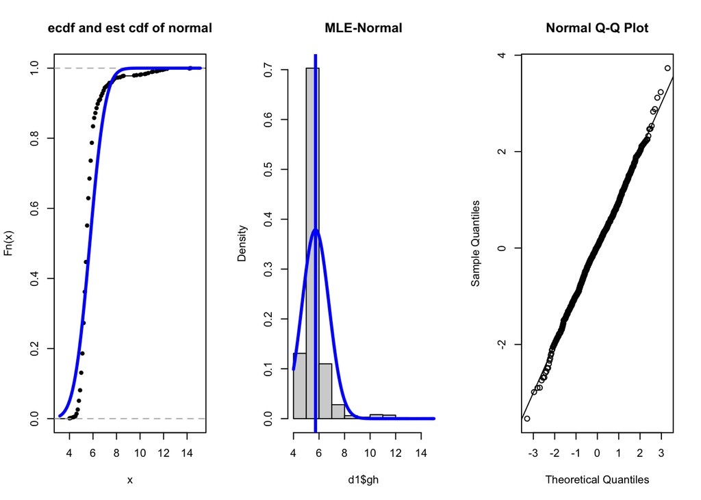

```r
nLL <- function(mean, sd){
  fs <- dnorm(
        x = d1$gh
      , mean = mean
      , sd = sd
      , log = TRUE
    )
  -sum(fs)
}
fit <- stats4::mle(
    nLL
  , start = list(mean = 1, sd = 1)
  , method = "L-BFGS-B"
  , lower = c(0, 0.01)
)


par(mfrow = c(1,3))
plot(ecdf(d1$gh), main = "ecdf and est cdf of normal")
curve(
    pnorm(x, coef(fit)[1], coef(fit)[2])
  , add = TRUE
  , col = "blue"
  , lwd = 3
)
hist(d1$gh, freq = FALSE, main = "MLE-Normal")
curve(
    dnorm(x, coef(fit)[1], coef(fit)[2])
  , add = TRUE
  , col = "blue"
  , lwd = 3
)
median_norm <- qnorm(0.5, mean=coef(fit)[1], sd=coef(fit)[2])
abline(v=median_norm, col="blue",lwd=3)

U <- runif(1000)
Y <- qnorm(U)
qqnorm(Y)
abline(0,1)
```

```r
#lm(d1$gh ~ 1) %>% summary
```

### 2.2.2 MLE-Gamma

```r
require(stats4)
(shape_hat <- xbar^2/s2)
```

```
## [1] 29.59754
```

```r
(scale_hat <- s2/xbar)
```

```
## [1] 0.1934147
```

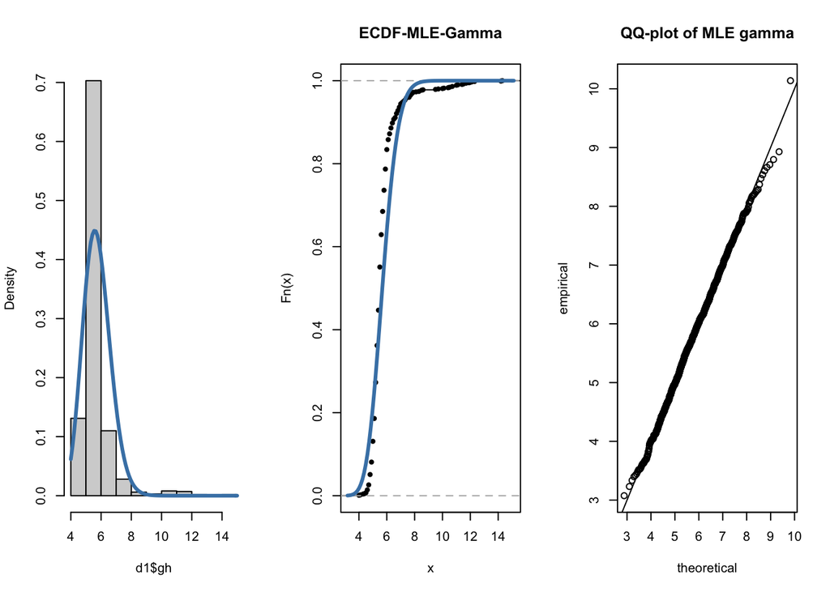

```r
nll <- function(shape, scale){
 fs <- dgamma(x=d1$gh, shape = shape, scale = scale, log = TRUE)
 -sum(fs)
}
m1 <- stats4::mle(
    nll
  , method = "L-BFGS-B"
  , lower = c(0,0)
  , start = list(shape = 29.59754, scale = 0.1934147)
)


par(mfrow = c(1,3))
hist(d1$gh, main = "", freq = FALSE)
curve(dgamma(x, shape = m1@coef[1], scale = m1@coef[2]), add = TRUE, lwd = 3, col = "steelblue")


plot(ecdf(d1$gh), main = "ECDF-MLE-Gamma")
curve(pgamma(x, shape = m1@coef[1], scale = m1@coef[2]), add = TRUE, lwd = 3, col = "steelblue")




U <- runif(1000)
Y <- qgamma(U, shape = shape_hat, scale = scale_hat)
pts <- ppoints(1000)
theoretical_q <- qgamma(pts, shape = shape_hat, scale = scale_hat)
sample_q <- quantile(Y, pts)
plot(theoretical_q,sample_q, main="QQ-plot of MLE gamma",xlab="theoretical", ylab="empirical")
abline(0,1)
```

### 2.2.3 MLE-Weibull

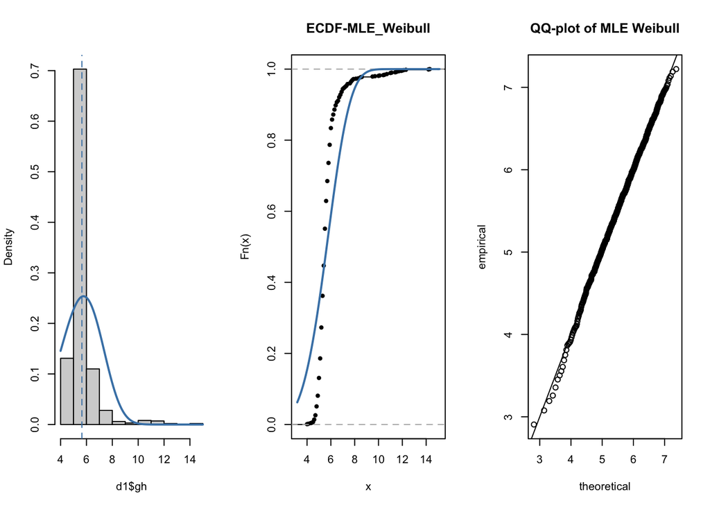

```r
par(mfrow = c(1,3))


wll <- function(shape_weib, scale_weib){
 fs <- dweibull(x=d1$gh, shape = shape_weib, scale = scale_weib, log = TRUE)
 -sum(fs)
}
w1 <- stats4::mle(
    wll
  , method = "L-BFGS-B"
  , lower = c(0,0.01)
  , start = list(shape_weib = 10.00008, scale_weib = 6)
)


par(mfrow = c(1,3))
hist(d1$gh, main = "", freq = FALSE)
curve(dweibull(x, shape = w1@coef[1], scale = w1@coef[2]), add = TRUE, lwd = 2, col = "steelblue")
abline(v=qweibull(0.5,shape= w1@coef[1], scale = w1@coef[2]),lty=2,col = "steelblue")

plot(ecdf(d1$gh), main = "ECDF-MLE_Weibull")
curve(pweibull(x, shape = w1@coef[1], scale = w1@coef[2]), add = TRUE, lwd = 2, col = "steelblue")



U <- runif(1000)
Y <- qweibull(U, shape = shape_weib, scale = scale_weib)
ps <- ppoints(1000)
theoretical <- qweibull(ps, shape = shape_weib, scale = scale_weib)
sample <- quantile(Y, ps)
plot(theoretical,sample, main="QQ-plot of MLE Weibull",xlab="theoretical", ylab="empirical")
abline(0,1)
```

## 2.3 MM Height:

### 2.3.1 MM-Normal

```r
par(mfrow = c(1,3))
hist(d1$ht, freq = FALSE, main = "Histogram of Height", breaks=10,)
#parameters
(xbar <- mean(d1$ht))
```

```
## [1] 160.7419
```

```r
(s2 <- var(d1$ht))
```

```
## [1] 53.58476
```

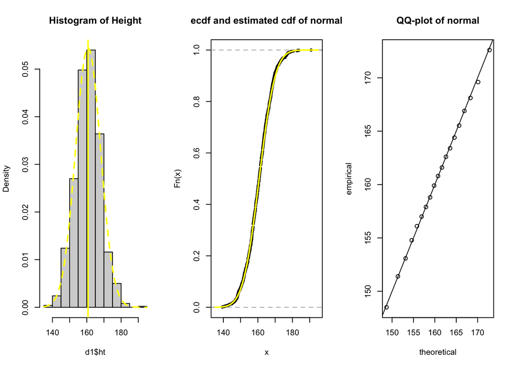

```r
#estimated pdf
curve(dnorm(x, mean=xbar, sd = sqrt(s2)),add=TRUE, lwd=2, col="yellow",lty=2)
#norm_median
abline(v=qnorm(0.5, mean=xbar, sd = sqrt(s2)),lwd=2,col="yellow")

#ecdf, estimated cdf
plot(ecdf(d1$ht),main="ecdf and estimated cdf of normal")
curve(pnorm(x, mean=xbar, sd=sqrt(s2)),add=TRUE, lwd=2, col="yellow")

#QQplot
sq <- seq(0.05,0.95,by=0.05)
#empirical
qt <- quantile(d1$ht, sq)
#theoretical
qn <- qnorm(sq, mean=xbar, sd=sqrt(s2))
plot(qn,qt, main="QQ-plot of normal",xlab="theoretical", ylab="empirical")
# y=x line
abline(0,1)
```

The QQplot shows that points fall on the y=x line. This means that estimated distribution matches the empirical distribution.

### 2.3.2 MM-Gamma

```r
par(mfrow = c(1,3))
hist(d1$ht, freq = FALSE, main = "Histogram of Height", breaks=10)
#parameters
(shape_hat <- xbar^2/s2)
```

```
## [1] 482.1886
```

```r
(scale_hat <- s2/xbar)
```

```
## [1] 0.333359
```

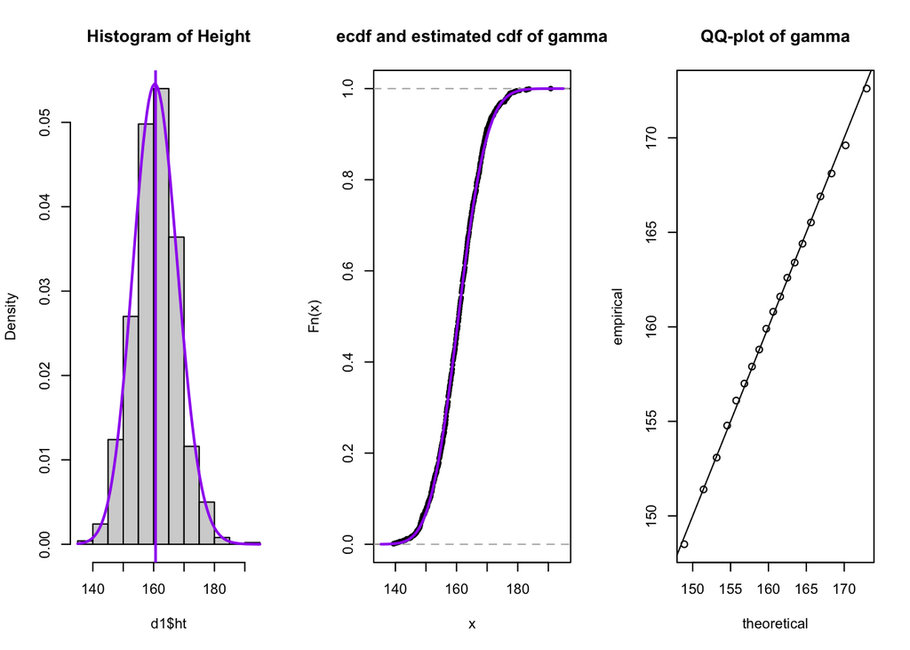

```r
#est pdf
curve(dgamma(x, shape=shape_hat, scale=scale_hat),add =T,lwd=2, col="purple")

#meida
abline(v=qgamma(0.5, shape=shape_hat, scale=scale_hat),col="purple",lwd=2)
#(qgamma(0.5, shape=shape_hat, scale=scale_hat))

#ecdf
plot(ecdf(d1$ht),main="ecdf and estimated cdf of gamma")
#est ecdf
curve(pgamma(x, shape=shape_hat,scale=scale_hat),add=TRUE,lwd=2, col="purple")

#QQ-plot
sq <- seq(0.05,0.95,by=0.05)
qt <- quantile(d1$ht, sq)
qga <- qgamma(sq, shape=shape_hat,scale=scale_hat)

plot(qga,qt, main="QQ-plot of gamma",xlab="theoretical", ylab="empirical")
abline(0,1)
```

The QQplot shows that points fall on the y=x line. This means that estimated distribution matches the empirical distribution.

### 2.3.3 MM-Weibull

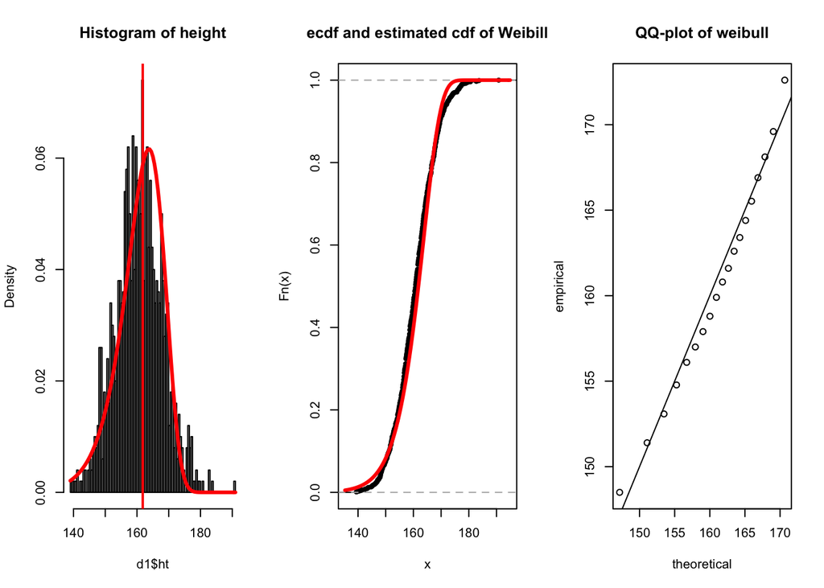

```r
par(mfrow = c(1,3))
#parameters
var.weib <- function(k,m_hat, var_hat){
  mean_w2<- (m_hat/gamma(1+1/k))^2
  var_w <- (gamma(1+2/k)-(gamma(1+1/k))^2)
  out <- mean_w2 * var_w - var_hat
  return(out)
}

x=seq(10,40, by=0.1)
mm.opt <- optimize(f=function(x){
  abs(var.weib(k=x, m_hat=mean(d1$ht),var_hat=var(d1$ht)))
}, lower=10, upper=100)
mm.weib.k <- mm.opt$minimum
mm.weib.lambda=(xbar/gamma(1+1/mm.weib.k))

shape_weib = mm.weib.k
scale_weib= mm.weib.lambda

#est pdf
hist(d1$ht, freq = FALSE, main = "Histogram of height", breaks=100)
curve(dweibull(x,shape=shape_weib, scale=scale_weib),  add=TRUE, lwd=3, col="red")
#meidan
abline(v=qweibull(0.5, shape = shape_weib, scale = scale_weib), col="red",lwd=2)
#(qweibull(0.5, shape=shape, scale=scale))

#ecdf
plot(ecdf(d1$ht),main="ecdf and estimated cdf of Weibill")
#est ecdf
curve(pweibull(x, shape=shape_weib,scale=scale_weib),add=T,lwd=3, col="red")

#QQ-plot
sq <- seq(0.05,0.95,by=0.05)
qt <- quantile(d1$ht, sq)
qga <- qweibull(sq, shape=shape_weib,scale=scale_weib)
plot(qga,qt, main="QQ-plot of weibull",xlab="theoretical", ylab="empirical")
abline(0,1)
```

## 2.4 MLE-Height

### 2.4.1 MLE-normal

```r
require(stats4)
nLL <- function(mean, sd){
  fs <- dnorm(
        x = d1$ht
      , mean = mean
      , sd = sd
      , log = TRUE
    )
  -sum(fs)
}
fit <- mle(
    nLL
  , start = list(mean = 1, sd = 1)
  , method = "L-BFGS-B"
  , lower = c(0, 0.01)
)
```

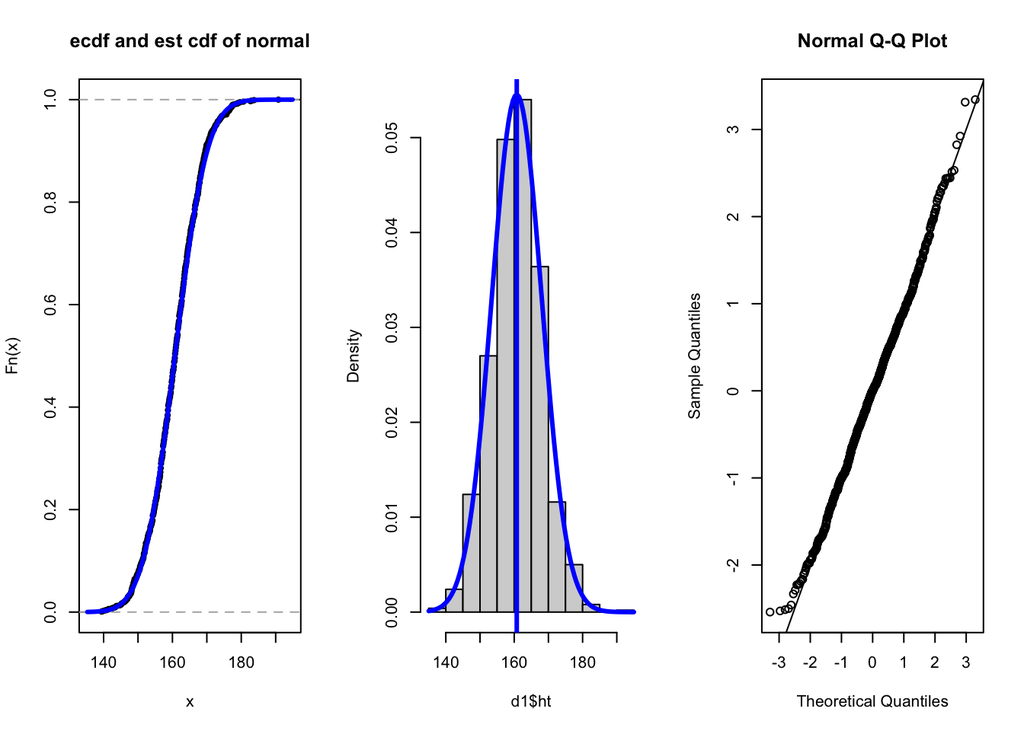

```r
par(mfrow = c(1,3))
plot(ecdf(d1$ht), main = "ecdf and est cdf of normal")
curve(
    pnorm(x, coef(fit)[1], coef(fit)[2])
  , add = TRUE
  , col = "blue"
  , lwd = 3
)
hist(d1$ht, freq = FALSE, main = "")
curve(
    dnorm(x, coef(fit)[1], coef(fit)[2])
  , add = TRUE
  , col = "blue"
  , lwd = 3
)
#median
abline(v=qnorm(0.5, mean=xbar, sd=s2), col="blue",lwd=3)

U <- runif(1000)
Y <- qnorm(U)
qqnorm(Y)
abline(0,1)
```

### 2.4.2 MLE-Gamma

```r
#gamma
(shape_hat <- xbar^2/s2)
```

```
## [1] 482.1886
```

```r
(scale_hat <- s2/xbar)
```

```
## [1] 0.333359
```

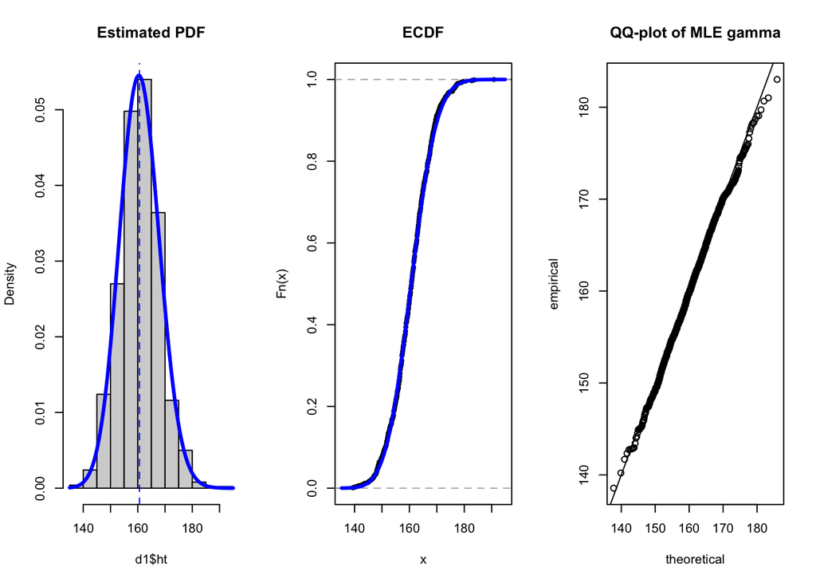

```r
nll <- function(shape, scale){
 fs <- dgamma(x=d1$ht, shape = shape, scale = scale, log = TRUE)
 -sum(fs)
}
m1 <- stats4::mle(
    nll
  , method = "L-BFGS-B"
  , lower = c(0,0)
  , start = list(shape = 482.1886, scale = 0.333359)
)


par(mfrow = c(1,3))
hist(d1$ht, main = "Estimated PDF", freq = FALSE)
curve(dgamma(x, shape = m1@coef[1], scale = m1@coef[2]), add = TRUE, lwd = 3, col = "blue")
abline(v=qgamma(0.5, shape = shape_hat, scale = scale_hat),col ="blue", lty=2)

plot(ecdf(d1$ht), main = "ECDF")
curve(pgamma(x, shape = m1@coef[1], scale = m1@coef[2]), add = TRUE, lwd = 3, col = "blue")

U <- runif(1000)
Y <- qgamma(U, shape = shape_hat, scale = scale_hat)
ps <- ppoints(1000)
theoretical <- qgamma(ps, shape = shape_hat, scale = scale_hat)
sample <- quantile(Y, ps)
plot(theoretical, sample,main="QQ-plot of MLE gamma",xlab="theoretical", ylab="empirical")
abline(0,1)
```

### 2.4.3 MLE-Weibull

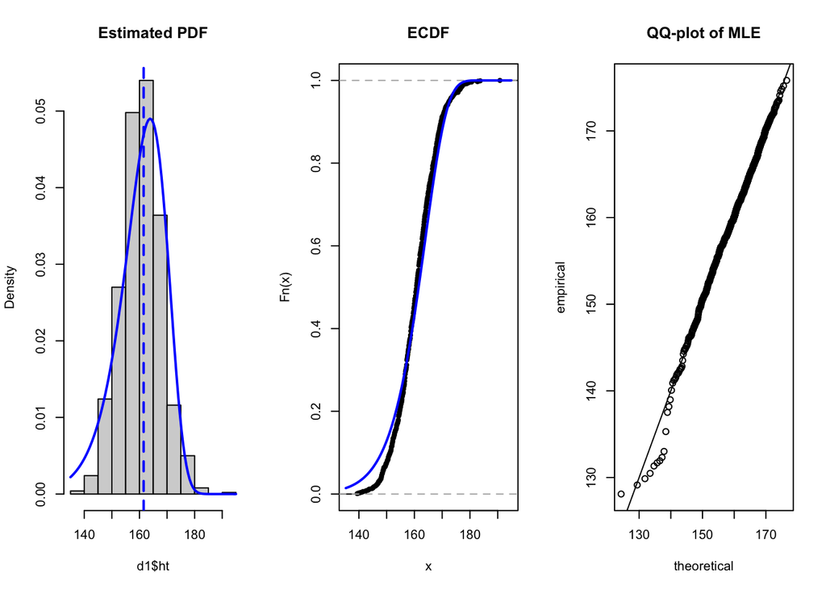

```r
par(mfrow = c(1,3))
shape_weib = mm.weib.k
scale_weib= mm.weib.lambda

require(stats4)
wll <- function(shape_weib, scale_weib){
 fs <- dweibull(x=d1$ht, shape = shape_weib, scale = scale_weib, log = TRUE)
 -sum(fs)
}
w1 <- stats4::mle(
    wll
  , method = "L-BFGS-B"
  , lower = c(1,0.01)
  , start = list(shape_weib = 27.45942, scale_weib = 163.9807)
)


par(mfrow = c(1,3))
hist(d1$ht, main = "Estimated PDF", freq = FALSE)
curve(dweibull(x, shape = w1@coef[1], scale = w1@coef[2]), add = TRUE, lwd = 2, col = "blue")
abline(v=qweibull(0.5, shape = w1@coef[1], scale = w1@coef[2]),col="blue",lwd=2, lty=2)

plot(ecdf(d1$ht), main = "ECDF")
curve(pweibull(x, shape = w1@coef[1], scale = w1@coef[2]), add = TRUE, lwd = 2, col = "blue")


U <- runif(1000)
Y <- qweibull(U, shape = shape_weib, scale = scale_weib)
ps <- ppoints(1000)
theoretical <- qweibull(ps, shape = shape_weib, scale = scale_weib)
sample <- quantile(Y, ps)
plot(theoretical, sample,main="QQ-plot of MLE",xlab="theoretical", ylab="empirical")
abline(0,1)
```